# Auto-Regressive Models

Autoregressive models are based on the idea that the current value of the time series, $X_t$, can be explained as a function of $p$ past values, $X_{t-1}, X_{t-2}, \cdots, X_{t-p}$, where $p$ determines the number of steps into the past needed to forecast the current value.

An **autoregressive model** of order $p$. abbreviated $AR(p)$, is of the form

$$ X_t - \mu = \phi_1 (X_{t-1} - \mu) + \phi_2 (X_{t-2} - \mu) + \cdots + \phi_p (X_{t-p} - \mu) + W_t \\ = \alpha + \phi_1 X_{t-1} + \phi_2 X_{t-2} + \cdots + \phi_p X_{t-p} + W_t $$

where $X_t$ is stationary, $W_t \sim \mathcal{N}(0, \sigma_W)$, and $\phi_1, \cdots, \phi_p$ are parameters with $\phi_p \neq 0$. For most of cases we will assume $\alpha=0$.

We can write the $AR(p)$ model in terms of the backshift operator $B$ as

$$ (1 - \phi_1 B - \phi_2 B^2 - \cdots - \phi_p B^p) X_t = \phi(B)X_t = W_t $$

where

$$ \phi(B) = 1 - \phi_1 B - \phi_2 B^2 - \cdots - \phi_p B^p $$

defines the **autoregressive operator**.

## The $AR(1)$ Model

Consider the $AR(1)$ model, given by $X_t = \phi X_{t-1} + W_t$. Iterating backward $k$ times, we get

$$ X_t = \phi X_{t-1} + W_t = \phi (\phi X_{t-2} + W_{t-1}) + W_{t-2} \\ = \phi^2 X_{t-2} + \phi W_{t-1} + W_{t-2} \\ \vdots \\ =\phi^k X_{t-k} + \sum_{j=0}^{k-1} \phi^j W_{t-j} $$

This method suggests that, by continuing to iterate backward, and provided that $|\phi|<1$ and $\sup_t var(X_t) < \infty$, we can represent an $AR(1)$ model as a linear process given by

$$ X_t = \sum_{j=0}^{\infty} \phi^j W_{t-j} $$

which is stationary.

### Expected Value of the $AR(1)$ Model

Given the $AR(1)$ model

$$ X_t = \sum_{j=0}^{\infty} \phi^j W_{t-j} $$

the expected value is given by

$$ \mathbb{E}[X_t] = \sum_{j=0}^{\infty} \phi^j \mathbb{E}[W_{t-j}] = 0 $$

### Autocovariance of the $AR(1)$ Model

Given the $AR(1)$ model

$$ X_t = \sum_{j=0}^{\infty} \phi^j W_{t-j} $$

the autocovariance is

$$ cov(X_{t+h}, X_t) = \mathbb{E}\left[ \left( \sum_{j=0}^{\infty} \phi^j W_{t+h-j} \right) \left( \sum_{k=0}^{\infty} \phi^k W_{t-k} \right) \right] \\ = \mathbb{E}\left[ \left( W_{t+h} + \cdots + \phi^h W_{t} + \phi^{h+1} W_{t-1} + \cdots \right) \left( W_t + \phi W_{t-1} + \cdots \right) \right] \\ = \sigma_W^2 \sum_{j=0}^{\infty} \phi^{h+j} \phi^j = \sigma_W^2 \phi^{ħ} \sum_{j=0}^{\infty} \phi^{2j} \\ = \frac{\sigma_W^2 \phi^h}{1-\phi^2} $$

### Example of an $AR(1)$ Process

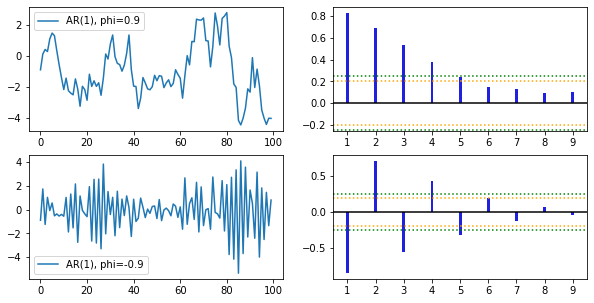

```python
figure
```

## Explosive AR Models and Causality

In the $AR(1)$ model, the convergence of the stationary form

$$ X_t = \sum_{j=0}^{\infty} \phi^j W_{t-j} $$

is ensured while $|\phi|<1$, because otherwise the value of $X_t$ become large in magnitude.

### Example of Explosive AR(1) Model

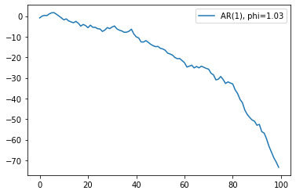

```python
ax.figure
```

We can, however, modify that argument to obtain a stationary model as follows. Write $X_{t+1} = \phi X_t + W_{t+1}$, in which case,

$$ X_t = \phi^{-1} X_{t+1} - \phi^{-1} W_{t+1} = \phi^{-1}(\phi^{-1} X_{t+2} - \phi^{-1} W_{t+2} ) - \phi^{-1} W_{t+1} \\ \vdots \\ X_t = \phi^{-k}X_{t+k} - \sum_{j=1}^{k-1}\phi^{-j}W_{t+j} $$

by iterating forward k steps. Because $|\phi|^{-1} < 1$, this result suggests the stationary future dependent AR(1) model

$$ X_t = -\sum_{j=1}^{\infty}\phi^{-j}W_{t+j} $$

Unfortunately, this model is useless.

## Every Explosion Has a Cause

Excluding explosive models from consideration is not a problem because the models have causal counterparts. For example, if

$$ X_t = \phi X_{t-1} + W_t $$

with $|\phi| > 1$ and $W_t \sim_{i.i.d.} \mathcal{N}(0, \sigma_W^2)$, then $X_t$ is a non-causal stationary Gaussian process with $E(X_t)=0$ and

$$ \gamma_X(h) = \frac{\sigma_W^2 \phi^{-2} \phi^{-h}}{1-\phi^{-2}} $$

Thus, the causal process defined by

$$ Y_t = \phi^{−1} Y_{t-1} + V_t $$

which has the form of a causal $AR(1)$ model.

## Introduction to AR Polynomial

Consider the $AR(1)$ model in operator form

$$ \phi(B)X_t = W_t $$

Let's assume that the inverse operator exists, then

$$ \phi^{-1}(B) \phi(B)X_t = X_t = \phi^{-1}(B) W_t = (1 + \phi B + + \phi^2 B^2 + \cdots + \phi^j B^j + \cdots) W_t $$

where $\phi^{-1}(B) = (1 + \phi B + + \phi^2 B^2 + \cdots + + \phi^j B^j + \cdots) $ because of the form of the stationary solution.

Let's consider the polynomial

$$ \phi(z) = 1 - \phi z $$

where $z$ is a complex number and $|\phi| < 1$, then

$$ \phi^{-1}(z) = \frac{1}{1 - \phi z} = 1 + \phi z + \phi^2 z^2 + \cdots + \phi^j z^j + \cdots \;\;\;, |z| \leq 1 $$

because of the convergence of geometric serie, and the coefficients of $B^j$ in $\phi^{-1}(B)$ are the same as the coefficients of $z^j$ in $\phi^{-1}(z)$. In other words, we may treat the backshift operator, $B$, as a complex number, $z$.